# {fastknn}を使った特徴量エンジニアリング

UPDATE: 2022-12-15 20:54:40

# はじめに

ここでは[`{FastKNN}`](https://github.com/davpinto/fastknn)の使い方まとめておく。`{FastKNN}`を使えば、高速にk最近傍分類器が作れたり、K近傍を用いた特徴量エンジニアリングが可能。通常の`{knn}`よりも50倍は速いそうで、Kaggleなんかでは特徴量エンジニアリングの手法として使われているK近傍を用いた特徴量エンジニアリングも可能。とりあえずこのパッケージの特徴は下記の通り。

- 数秒で大きなデータセット(>100k)でもKNN分類器が構築できる
- 「dist」推定量を使用して、より調整された確率を予測し、Loglossを減らせる
- クロスバリデーションを使用して、さまざまな損失関数に従って最良のパラメタ数kを見つけられる
- 分類決定境界をプロットできる
- 特徴量エンジニアリングとして、新たな特徴量を抽出できる

## パッケージインストール

```r
library(remotes)
install_github("davpinto/fastknn")
library(fastknn)
```

`{RANN}`、`{foreach}`、`{Metrics}`、`{matrixStats}`、`{ggplot2}`、`{viridis}`などのパッケージに依存しているみたいです。`{RANN}`や`{foreach}`があるように高速化、並列化することで、大きなサイズのデータでも高速に動作するパッケージであることがわかる。

## K近傍を用いた特徴量エンジニアリング

`{fastknn}`を使うことで、K近傍を用いた特徴量エンジニアリングが可能。ざっくり説明すると、クラスラベルの数cと近傍数kの間の距離をもとにk×c個の特徴量を生成。なので、クラス数c=3で、近傍数をk=5とすると、15個の特徴量が生成される。

イメージとしては、あるクラスに属する訓練データの最近傍までの距離を1つ目の特徴量として、第2近傍までの距離の和(最近傍までの距離+第2近傍までの距離)を2つ目の特徴量として……という感じでこれをkに関して繰り返すことで特徴量を作る。

具体的な計算イメージについては、こちらの記事に詳しくのっている。

- [Python: k-NN Feature Extraction について](https://blog.amedama.jp/entry/knn-feature-extraction)

ここでは、`{fastknn}`のGithub上の例を再現する。この例では、K近傍を用いた特徴量エンジニアリングを行うことで、10％もAccuracyが向上している。

```r
library(mlbench)
library(caTools)
library(glmnet)

# Load data
data("Ionosphere", package = "mlbench")
x <- data.matrix(subset(Ionosphere, select = -Class))
y <- Ionosphere$Class

# Remove near zero variance columns
x <- x[, -c(1,2)]

# Split data
set.seed(123)
tr.idx <- which(sample.split(Y = y, SplitRatio = 0.7))
x.tr <- x[tr.idx,]
x.te <- x[-tr.idx,]
y.tr <- y[tr.idx]
y.te <- y[-tr.idx]

# GLM with original features
glm <- glmnet(x = x.tr, y = y.tr, family = "binomial", lambda = 0)
yhat <- drop(predict(glm, x.te, type = "class"))
yhat1 <- factor(yhat, levels = levels(y.tr))

# Generate KNN features
set.seed(123)
new.data <- knnExtract(xtr = x.tr, ytr = y.tr, xte = x.te, k = 3)
# GLM with KNN features
glm <- glmnet(x = new.data$new.tr, y = y.tr, family = "binomial", lambda = 0)
yhat <- drop(predict(glm, new.data$new.te, type = "class"))
yhat2 <- factor(yhat, levels = levels(y.tr))

# Performance
list(
sprintf("Accuracy: %.2f", 100 * (1 - classLoss(actual = y.te, predicted = yhat1))),
sprintf("Accuracy: %.2f", 100 * (1 - classLoss(actual = y.te, predicted = yhat2)))
)
```

```
## [[1]]
## [1] "Accuracy: 83.81"
##
## [[2]]
## [1] "Accuracy: 96.19"
```

K近傍を用いた特徴量エンジニアリングを行っている部分はここ。kには近傍の点としていくつ使用するかを設定。

```r
knnExtract(xtr = x.tr, ytr = y.tr, xte = x.te, k = 3)
```

```
## $new.tr
##            knn1      knn2      knn3     knn4      knn5      knn6
##   [1,] 1.499212  3.811036  6.275441 0.904031  2.150202  3.437391
##   [2,] 2.783883  5.664107  8.565420 2.618879  5.395238  8.385702
##   [3,] 3.789290  7.609333 11.484334 3.764956  7.551773 11.382875
##   [4,] 1.965208  4.260902  6.907153 1.269413  2.646760  4.329151
##   [5,] 0.440177  0.921218  1.585418 0.956144  2.448385  4.278621
##   [6,] 2.422808  5.555677  8.738436 0.671978  1.418216  2.544402
##   [7,] 3.350669  6.757612 10.364046 2.791661  5.613947  8.571800
##   [8,] 1.855603  4.495724  7.294386 0.612756  1.245848  2.174540
##   [9,] 2.401206  5.359756  8.533233 2.078666  4.286245  6.499967
##  [10,] 2.901313  6.114812  9.482911 3.259588  6.634625 10.069889
##  [11,] 1.707760  3.439244  5.194714 0.381040  0.844549  1.311158
##  [12,] 5.291503 10.637882 16.023047 5.484870 10.979314 16.498124
##  [13,] 1.916580  3.894994  5.909458 1.158238  2.388691  3.635843
```

[output cut: 341 more lines]

アウトプットには訓練データとテストデータ用の新しい特徴量が生成される。

```r
str(new.data)
```

[output not shown]

## ナニヲシテイルノカ？

K近傍を用いた特徴量エンジニアリングは何をやっているのか…。ざっくり説明すると、KNNは元の空間の非線形写像を作り、それを線形のものに射影することで、クラスを線形に分離できる特徴量を生成しているとのことです。

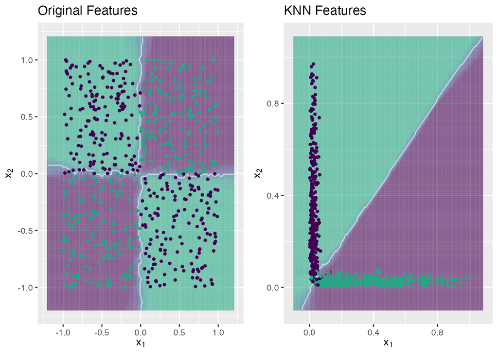

```r
library("caTools")
library("fastknn")
library("ggplot2")
library("gridExtra")

# Load data
data("chess")
x <- data.matrix(chess$x)
y <- chess$y

# Split data
set.seed(123)
tr.idx <- which(sample.split(Y = y, SplitRatio = 0.7))
x.tr <- x[tr.idx,]
x.te <- x[-tr.idx,]
y.tr <- y[tr.idx]
y.te <- y[-tr.idx]

# Feature extraction with KNN
set.seed(123)
new.data <- knnExtract(x.tr, y.tr, x.te, k = 1)
# Decision boundaries
g1 <- knnDecision(x.tr, y.tr, x.te, y.te, k = 10) +
  labs(title = "Original Features")
g2 <- knnDecision(new.data$new.tr, y.tr, new.data$new.te, y.te, k = 10) +
  labs(title = "KNN Features")
grid.arrange(g1, g2, ncol = 2)
```

```r
# Load data
data("spirals")
x <- data.matrix(spirals$x)
y <- spirals$y

# Split data
set.seed(123)
tr.idx <- which(sample.split(Y = y, SplitRatio = 0.7))
x.tr <- x[tr.idx,]
x.te <- x[-tr.idx,]
y.tr <- y[tr.idx]
y.te <- y[-tr.idx]

# Feature extraction with KNN
set.seed(123)
new.data <- knnExtract(x.tr, y.tr, x.te, k = 1)
```

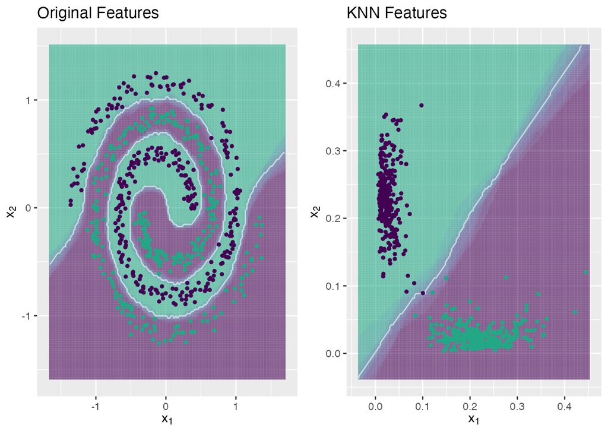

```r
# Decision boundaries
g1 <- knnDecision(x.tr, y.tr, x.te, y.te, k = 10) +
   labs(title = "Original Features")
g2 <- knnDecision(new.data$new.tr, y.tr, new.data$new.te, y.te, k = 10) +
   labs(title = "KNN Features")
grid.arrange(g1, g2, ncol = 2)
```

## 最適なkを求める

ハイパーパラメタであるkを決める必要があるのですが、このパッケージには、様々な指標のもとでクロスバリデーションを行い、最適なkを決めることができるようです。「overall_error」「mean_error」「auc」「logloss」が利用可能です。

この例の場合、loglossのもとでクロスバリデーションした結果、loglossを最も小さくするkは10であることがわかります。

```r
# Load dataset
library("mlbench")
data("Sonar", package = "mlbench")
x <- data.matrix(Sonar[, -61])
y <- Sonar$Class

# 5-fold CV using log-loss as evaluation metric
set.seed(123)
cv.out <- fastknnCV(x,
                    y,
                    k = 3:15,
                    method = "vote", #method = "dist"もある
                    folds = 5,
                    eval.metric = "logloss")
cv.out$cv_table
```

```
##       fold_1    fold_2    fold_3    fold_4    fold_5      mean  k
## 1  1.0185769 4.3488958 5.2774367 3.5390275 1.7839039 3.1935682  3
## 2  0.3302963 3.5667636 4.5300572 2.7776147 1.0502739 2.4510011  4
## 3  0.4046927 2.8207457 3.7682707 2.8348932 0.3424366 2.0342078  5
## 4  0.4655162 2.8307567 2.2128757 1.2546941 0.3610754 1.4249836  6
## 5  0.5302694 2.0623844 2.2345220 0.4860235 0.4155828 1.1457564  7
## 6  0.5468362 2.1109205 2.2323124 0.5080782 0.4481816 1.1692658  8
## 7  0.5782588 2.1231117 1.4562867 0.5286501 0.4478363 1.0268287  9
## 8  0.5947111 0.5556146 0.7008334 0.5156674 0.4565729 0.5646799 10
## 9  0.6152572 0.5767084 0.6726436 0.5208554 0.4610948 0.5693119 11
## 10 0.6263350 0.5951938 0.6712564 0.5339942 0.5083115 0.5870182 12
## 11 0.6119226 0.5866577 0.6610566 0.5430764 0.5154826 0.5836391 13
## 12 0.6137801 0.5715341 0.6623809 0.5434475 0.5298594 0.5842004 14
## 13 0.6132759 0.5883311 0.6594093 0.5739258 0.5543286 0.5978541 15
```